# GDP Prediction for ASEAN Member Countries

Elvina

2023-06-17

#1. Data Description The data we are using consists of information from 1990 to 2021 and includes ASEAN member countries. Currently, there are 11 ASEAN member countries, but in 2021, there were only 10 member countries. Therefore, based on the years we are considering, we will only use data for the 10 countries that were already part of ASEAN in 2021.

1. Countries: Character variable of each Countries
2. Year : Numerical variable of Year
3. GDP : Numerical variable of GDP in the particular year (USD) [!= 0]
4. FDI : Numerical variable of FDI (Foreign Direct Investment) in the particular year (USD) [!= 0]
5. HDI : Numerical variable of HDI (Human Development Index) in the particular year [!= 0]
6. Portofolio_Investment: Numerical variable of Portfolio Investment in the particular year (USD) [!= 0]

Data source: https://databank.worldbank.org/reports.aspx?source=2&series=BX.KLT.DINV.CD.WD&country=IDN https://databank.worldbank.org/reports.aspx?source=2&series=BN.KLT.PTXL.CD&country=IDN https://databank.worldbank.org/reports.aspx?source=2&series=NY.GDP.MKTP.CD&country=IDN https://countryeconomy.com/hdi/indonesia https://countryeconomy.com/hdi/malaysia https://countryeconomy.com/hdi/singapore https://countryeconomy.com/hdi/brunei https://countryeconomy.com/hdi/vietnam https://countryeconomy.com/hdi/laos https://countryeconomy.com/hdi/thailand https://countryeconomy.com/hdi/cambodia https://countryeconomy.com/hdi/philippines https://countryeconomy.com/hdi/myanmar

#2. Load Libraries and Data

```r
library(skimr)
library(ggplot2)
library(reshape2)
library(readxl)
library(dplyr)
library(caret)
library(rpart)
library(rpart.plot)
library(MLmetrics)
library(pROC)
df <- read_excel("dataset_gdp.xlsx")
head(df)
```

```
## # A tibble: 6 × 6
##   Countries  Year GDP                  HDI FDI        Portofolio_Investment
##   <chr>     <dbl> <chr>              <dbl> <chr>      <chr>
## 1 Indonesia  1990 106140727356.7     0.526 1093000000 93000000
## 2 Indonesia  1991 116621996217.10001 0.532 1482000000 12000000
## 3 Indonesia  1992 128026966580       0.54  1777000000 88000000
## 4 Indonesia  1993 158006700301.5     0.548 2004000000 -1805000000
## 5 Indonesia  1994 176892143931.5     0.558 2109000000 -3877000000
## 6 Indonesia  1995 202132028723.10001 0.569 4346000000 -4100000000
```

Above display head of our dataset.

#3. General Characteristic

```r
dim(df)
```

```
## [1] 320   6
```

The dataset that we use consist of 320 rows and 6 colomns.

```r
head(df)
```

```
## # A tibble: 6 × 6
##   Countries  Year GDP                  HDI FDI        Portofolio_Investment
##   <chr>     <dbl> <chr>              <dbl> <chr>      <chr>
## 1 Indonesia  1990 106140727356.7     0.526 1093000000 93000000
## 2 Indonesia  1991 116621996217.10001 0.532 1482000000 12000000
## 3 Indonesia  1992 128026966580       0.54  1777000000 88000000
## 4 Indonesia  1993 158006700301.5     0.548 2004000000 -1805000000
## 5 Indonesia  1994 176892143931.5     0.558 2109000000 -3877000000
## 6 Indonesia  1995 202132028723.10001 0.569 4346000000 -4100000000
```

```r
str(df)
```

```
## tibble [320 × 6] (S3: tbl_df/tbl/data.frame)
##  $ Countries            : chr [1:320] "Indonesia" "Indonesia" "Indonesia" "Indonesia" ...
##  $ Year                 : num [1:320] 1990 1991 1992 1993 1994 ...
##  $ GDP                  : chr [1:320] "106140727356.7" "116621996217.10001" "128026966580" "158006700301.5" ...
##  $ HDI                  : num [1:320] 0.526 0.532 0.54 0.548 0.558 0.569 0.578 0.589 0.585 0.59 ...
##  $ FDI                  : chr [1:320] "1093000000" "1482000000" "1777000000" "2004000000" ...
##  $ Portofolio_Investment: chr [1:320] "93000000" "12000000" "88000000" "-1805000000" ...
```

In this dataset, there are 6 variables.They are Countries, Year, GDP, HDI, FDI, and Portofolio_Investment.

Variable Year and HDI are numerical. Whereas, variable Countries, GDP, FDI, and Portofolio_Investment are categorized as characters. Actually, all variables except the Countries variable should be numerical. So, we have to change the type of the variables GDP, FDI, and Portofolio_Investment to numeric.

```r
df$GDP <- as.numeric(df$GDP)
df$FDI <- as.numeric(df$FDI)
df$Portofolio_Investment <- as.numeric(df$Portofolio_Investment)
str(df)
```

```
## tibble [320 × 6] (S3: tbl_df/tbl/data.frame)
##  $ Countries            : chr [1:320] "Indonesia" "Indonesia" "Indonesia" "Indonesia" ...
##  $ Year                 : num [1:320] 1990 1991 1992 1993 1994 ...
##  $ GDP                  : num [1:320] 1.06e+11 1.17e+11 1.28e+11 1.58e+11 1.77e+11 ...
##  $ HDI                  : num [1:320] 0.526 0.532 0.54 0.548 0.558 0.569 0.578 0.589 0.585 0.59 ...
##  $ FDI                  : num [1:320] 1.09e+09 1.48e+09 1.78e+09 2.00e+09 2.11e+09 ...
##  $ Portofolio_Investment: num [1:320] 9.30e+07 1.20e+07 8.80e+07 -1.80e+09 -3.88e+09 ...
```

Right now, there are 5 numeric variable, including Year, GDP, HDI, FDI, and Portofolio_Investment. The variable “Countries” is the only variable with the data type character.

```r
unique(df$Countries)
```

```
##  [1] "Indonesia"         "Malaysia"          "Singapore"
##  [4] "Philippines"       "Laos"              "Thailand"
##  [7] "Vietnam"           "Myanmar"           "Cambodia"
## [10] "Brunei Darussalam"
```

Variable countries has 10 unique values.

```r
unique(df$Year)
```

```
##  [1] 1990 1991 1992 1993 1994 1995 1996 1997 1998 1999 2000 2001 2002 2003 2004
## [16] 2005 2006 2007 2008 2009 2010 2011 2012 2013 2014 2015 2016 2017 2018 2019
## [31] 2020 2021
```

Variable year has 32 unique values.

```r
unique(df$GDP)
```

```
##   [1] 1.061407e+11 1.166220e+11 1.280270e+11 1.580067e+11 1.768921e+11
##   [6] 2.021320e+11 2.273697e+11 2.157490e+11 9.544555e+10 1.400014e+11
##  [11] 1.650210e+11 1.604469e+11 1.956606e+11 2.347725e+11 2.568369e+11
##  [16] 2.858686e+11 3.645705e+11 4.322167e+11 5.102286e+11 5.395801e+11
##  [21] 7.550942e+11 8.929691e+11 9.178699e+11 9.125241e+11 8.908148e+11
##  [26] 8.608542e+11 9.318774e+11 1.015619e+12 1.042272e+12 1.119100e+12
##  [31] 1.058689e+12 1.186093e+12 4.402418e+10 4.914315e+10 5.916755e+10
##  [36] 6.689484e+10 7.447836e+10 8.870534e+10 1.008554e+11 1.000053e+11
##  [41] 7.216750e+10 7.914842e+10 9.378974e+10 9.278395e+10 1.008455e+11
##  [46] 1.102024e+11 1.247495e+11 1.435341e+11 1.626912e+11 1.935478e+11
##  [51] 2.308139e+11 2.022576e+11 2.550166e+11 2.979520e+11 3.144431e+11
##  [56] 3.232772e+11 3.380620e+11 3.013548e+11 3.012555e+11 3.191122e+11
##  [61] 3.587916e+11 3.651751e+11 3.373379e+11 3.729810e+11 3.614434e+10
##  [66] 4.546616e+10 5.213026e+10 6.060348e+10 7.369085e+10 8.781099e+10
##  [71] 9.629589e+10 1.001242e+11 8.572831e+10 8.628466e+10 9.607448e+10
```

[output cut: 49 more lines]

Variable GDP has 318 unique values.

```r
unique(df$HDI)
```

```
##   [1] 0.526 0.532 0.540 0.548 0.558 0.569 0.578 0.589 0.585 0.590 0.595 0.604
##  [13] 0.612 0.621 0.619 0.632 0.639 0.643 0.646 0.657 0.664 0.671 0.678 0.683
##  [25] 0.687 0.695 0.699 0.704 0.710 0.716 0.709 0.705 0.640 0.648 0.656 0.663
##  [37] 0.679 0.689 0.700 0.703 0.721 0.722 0.724 0.732 0.735 0.736 0.747 0.756
##  [49] 0.762 0.769 0.773 0.780 0.785 0.792 0.797 0.803 0.805 0.807 0.810 0.806
##  [61] 0.727 0.737 0.748 0.758 0.770 0.779 0.789 0.802 0.820 0.831 0.833 0.840
##  [73] 0.845 0.851 0.875 0.881 0.887 0.892 0.910 0.915 0.920 0.923 0.928 0.930
##  [85] 0.934 0.935 0.940 0.943 0.939 0.598 0.599 0.603 0.606 0.609 0.620 0.625
##  [97] 0.630 0.633 0.638 0.645 0.650 0.658 0.659 0.668 0.667 0.674 0.685 0.692
## [109] 0.696 0.698 0.718 0.405 0.412 0.417 0.424 0.432 0.434 0.447 0.454 0.460
## [121] 0.466 0.470 0.476 0.484 0.493 0.500 0.510 0.511 0.525 0.543 0.551 0.563
## [133] 0.572 0.582 0.592 0.607 0.610 0.608 0.576 0.613 0.628 0.635 0.653 0.676
## [145] 0.697 0.706 0.712 0.730 0.743 0.746 0.778 0.781 0.790 0.795 0.804 0.800
## [157] 0.482 0.504 0.515 0.539 0.550 0.560 0.588 0.617 0.641 0.672 0.680 0.684
## [169] 0.688 0.333 0.343 0.356 0.363 0.369 0.374 0.381 0.385 0.392 0.401 0.410
## [181] 0.420 0.430 0.440 0.450 0.480 0.465 0.501 0.521 0.531 0.553 0.562 0.580
## [193] 0.600 0.378 0.383 0.387 0.390 0.397 0.400 0.404 0.407 0.416 0.425 0.441
## [205] 0.461 0.475 0.488 0.499 0.528 0.534 0.555 0.574 0.581 0.586 0.591 0.596
## [217] 0.593 0.775 0.786 0.798 0.799 0.801 0.808 0.809 0.813 0.818 0.822 0.825
## [229] 0.828 0.827 0.826 0.832 0.838 0.837 0.836 0.835 0.834 0.830 0.829
```

Variable HDI has 239 unique values.

```r
unique(df$FDI)
```

```
##   [1]   1093000000   1482000000   1777000000   2004000000   2109000000
##   [6]   4346000000   6194000000   4677000000   -240800000  -1865620964
##  [11]  -4550355286  -2977391857    145085549   -596923828   1896082770
##  [16]   8336257208   4914201435   6928480000   9318453650   4877369178
##  [21]  15292009410  20564938227  21200778608  23281742362  25120732060
##  [26]  19779127977   4541713739  20510310832  18909826044  24993551748
##  [31]  19175077748  21213080330   2332455289   3998448522   5183358086
##  [36]   5005642760   4341800916   4178239335   5078414948   5136514576
##  [41]   2163401816   3895263158   3787631579    553947368   3192894737
##  [46]   3218947368   4376052632   3924786635   7690731246   9071369835
##  [51]   7572512432    114664435  10885801852  15119439204   8895774251
##  [56]  11296279514  10619431583   9857162112  13470089921   9368469823
##  [61]   8304480742   9154921685   4058769679  18595649824   5574738855
##  [66]   4887094440   2204342221   4686312018   8550165227  11942852103
##  [71]  11432363956  15701783679   5958646074  18852989359  15515295182
```

[output cut: 49 more lines]

Variable FDI has 318 unique values.

```r
unique(df$Portofolio_Investment)
```

```
##   [1]     93000000     12000000     88000000  -1805000000  -3877000000
##   [6]  -4100000000  -5005000000   2632000000   1878000000   1792350000
##  [11]   1910730193    243802438  -1221849941  -2251268404  -4409156156
##  [16]  -4189585521  -4276626526  -5566080000  -1764251470 -10336230327
##  [21] -13201983671  -3806371952  -9908345748 -10872605550 -26066630212
##  [26] -16182680883 -18995589857 -21059012442  -9311908008 -21990288572
##  [31]  -3368889450  -5085568794    254725265   -170177693   1122328141
##  [36]    708598556   1649228924    435632561    268289120    247761291
##  [41]   -283102405   1024473684   2532105263    411842105   1398947368
##  [46]   -978157895  -8388684210   3700304285  -3435892078  -5388143289
##  [51]  23960720566    291400434 -14993955418  -8678199378 -20680452461
##  [56]    813576453  11883325039   7226139225   3331961296   3298702716
##  [61]  12431150396   7757677164  12033737658  -4551339878   1037442990
##  [66]    907007033  -2489799259   4965927417   7726174388  14979733663
##  [71]  15259770846  20186343108  -1609463024  16638655462  21055668237
```

[output cut: 34 more lines]

Variable Portofolio_Investment has 244 unique values.

#4. Data Summary

```r
BasicSummary <- function(df, dgts = 3){
m <- ncol(df)
varNames <- colnames(df)
varType <- vector("character",m)
topLevel <- vector("character",m)
topCount <- vector("numeric",m)
missCount <- vector("numeric",m)
levels <- vector("numeric", m)
for (i in 1:m){
x <- df[,i]
varType[i] <- class(x)
xtab <- table(x, useNA = "ifany")
levels[i] <- length(xtab)
nums <- as.numeric(xtab)
maxnum <- max(nums)
topCount[i] <- maxnum
maxIndex <- which.max(nums)
lvls <- names(xtab)
topLevel[i] <- lvls[maxIndex]
missIndex <- which((is.na(x)) | (x == "") | (x == " ") | (x == 0))
missCount[i] <- length(missIndex)
}
n <- nrow(df)
topFrac <- round(topCount/n, digits = dgts)
missFrac <- round(missCount/n, digits = dgts)
summaryFrame <- data.frame(variable = varNames, type = varType,
levels = levels, topLevel = topLevel,
topCount = topCount, topFrac = topFrac,
missFreq = missCount, missFrac = missFrac)
return(summaryFrame)
}
```

```r
BasicSummary(df)
```

```
##                variable   type levels          topLevel topCount topFrac
## 1             Countries tbl_df     10 Brunei Darussalam       32   0.100
## 2                  Year tbl_df     32              1990       10   0.031
## 3                   GDP tbl_df    318              <NA>        3   0.009
## 4                   HDI tbl_df    239             0.598        4   0.013
## 5                   FDI tbl_df    318             7e+06        2   0.006
## 6 Portofolio_Investment tbl_df    244              <NA>       47   0.147
##   missFreq missFrac
## 1        0    0.000
## 2        0    0.000
## 3        3    0.009
## 4        0    0.000
## 5        2    0.006
## 6       78    0.244
```

Here we can see that variable that there is 78 missing value in Portofolio_Investment variable, 3 missing value in GDP variable, and 2 missing value in FDI variable.

We will replace all of the missing values with the median value.

```r
skim(df)
```

Data summary

| Name | df |
| --- | --- |
| Number of rows | 320 |
| Number of columns | 6 |
| _______________________ |  |
| Column type frequency: |  |
| character | 1 |
| numeric | 5 |
| ________________________ |  |
| Group variables | None |

**Variable type: character**

| skim_variable | n_missing | complete_rate | min | max | empty | n_unique | whitespace |
| --- | --- | --- | --- | --- | --- | --- | --- |
| Countries | 0 | 1 | 4 | 17 | 0 | 10 | 0 |

**Variable type: numeric**

| skim_variable | n_missing | complete_rate | mean | sd | p0 | p25 | p50 | p75 | p100 | hist |
| --- | --- | --- | --- | --- | --- | --- | --- | --- | --- | --- |
| Year | 0 | 1.00 | 2.005500e+03 | 9.250000e+00 | 1.990000e+03 | 1.997750e+03 | 2.005500e+03 | 2.013250e+03 | 2.021000e+03 | ▇▇▇▇▇ |
| GDP | 3 | 0.99 | 1.517924e+11 | 2.096283e+11 | 8.655599e+08 | 1.186302e+10 | 7.741443e+10 | 2.217582e+11 | 1.186093e+12 | ▇▂▁▁▁ |
| HDI | 0 | 1.00 | 6.500000e-01 | 1.400000e-01 | 3.300000e-01 | 5.600000e-01 | 6.500000e-01 | 7.600000e-01 | 9.400000e-01 | ▂▅▇▆▃ |
| FDI | 2 | 0.99 | 2.470096e+10 | 6.407762e+10 | -4.947474e+09 | 3.811812e+08 | 2.474801e+09 | 1.243571e+10 | 3.940864e+11 | ▇▁▁▁▁ |
| Portofolio_Investment | 47 | 0.85 | 2.550471e+09 | 1.370570e+10 | -2.606663e+10 | -1.001144e+09 | 0.000000e+00 | 9.267017e+08 | 1.086039e+11 | ▇▂▁▁▁ |

in Here we can see the missing variable, mean, standard deviation and percentile at 0,25,50,75 and 100.

```r
summary(df)
```

```
##   Countries              Year           GDP                 HDI
##  Length:320         Min.   :1990   Min.   :8.656e+08   Min.   :0.3330
##  Class :character   1st Qu.:1998   1st Qu.:1.186e+10   1st Qu.:0.5573
##  Mode  :character   Median :2006   Median :7.741e+10   Median :0.6530
##                     Mean   :2006   Mean   :1.518e+11   Mean   :0.6499
##                     3rd Qu.:2013   3rd Qu.:2.218e+11   3rd Qu.:0.7638
##                     Max.   :2021   Max.   :1.186e+12   Max.   :0.9430
##                                    NA's   :3
##       FDI             Portofolio_Investment
##  Min.   :-4.947e+09   Min.   :-2.607e+10
##  1st Qu.: 3.812e+08   1st Qu.:-1.001e+09
##  Median : 2.475e+09   Median : 0.000e+00
##  Mean   : 2.470e+10   Mean   : 2.550e+09
##  3rd Qu.: 1.244e+10   3rd Qu.: 9.267e+08
##  Max.   : 3.941e+11   Max.   : 1.086e+11
##  NA's   :2            NA's   :47
```

In GDP, the minimum value is 8.656e+08, the Q1 is 1.186e+10 , the median is 7.741e+10 , the mean is 1.518e+11 , the Q3 is 2.218e+11 , the maximum value is 1.186e+12, and the standard deviation is 2.096283e+11.

In HDI, the minimum value is 0.3330 , the Q1 is 0.5573 , the median is 0.6530 , the mean is 0.6499 , the Q3 is 0.7638, the maximum value is 0.9430, and the standard deviation is 1.415552e-01.

#5. Data Preparation

```r
# Change missing value with the median value
df[df == 0] <- NA
df <- df %>% mutate_if(is.numeric, function(x) ifelse(is.na(x) | x == 0, median(x, na.rm = T), x))

# Check for Missing Value
BasicSummary(df)
```

```
##                variable   type levels          topLevel topCount topFrac
## 1             Countries tbl_df     10 Brunei Darussalam       32   0.100
## 2                  Year tbl_df     32              1990       10   0.031
## 3                   GDP tbl_df    317     77414425532.2        4   0.013
## 4                   HDI tbl_df    239             0.598        4   0.013
## 5                   FDI tbl_df    318             7e+06        2   0.006
## 6 Portofolio_Investment tbl_df    243           7905500       78   0.244
##   missFreq missFrac
## 1        0        0
## 2        0        0
## 3        0        0
## 4        0        0
## 5        0        0
## 6        0        0
```

All missing value have been change to median of the particular column.

#6. Check for Variable correlation #Heatmap

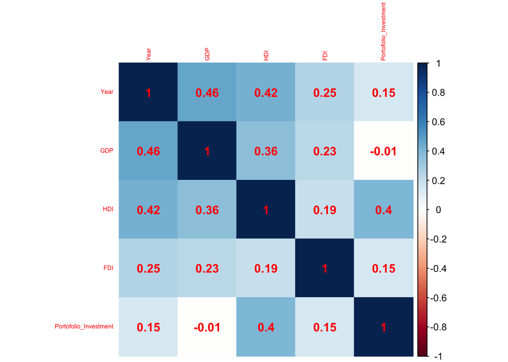

```r
library(corrplot)
numeric_df <- subset(df, select = -c(Countries))
df_cor_mat <- round(cor(numeric_df), 2)
corrplot(df_cor_mat,method = "color", tl.cex = 0.5, addCoef.col = "red")
```

Based on the heatmap above, the top 2 variables that have the highest correlation with GDP are Year and HDI.

#7. Assumption Checking

## A. Check for the linearity

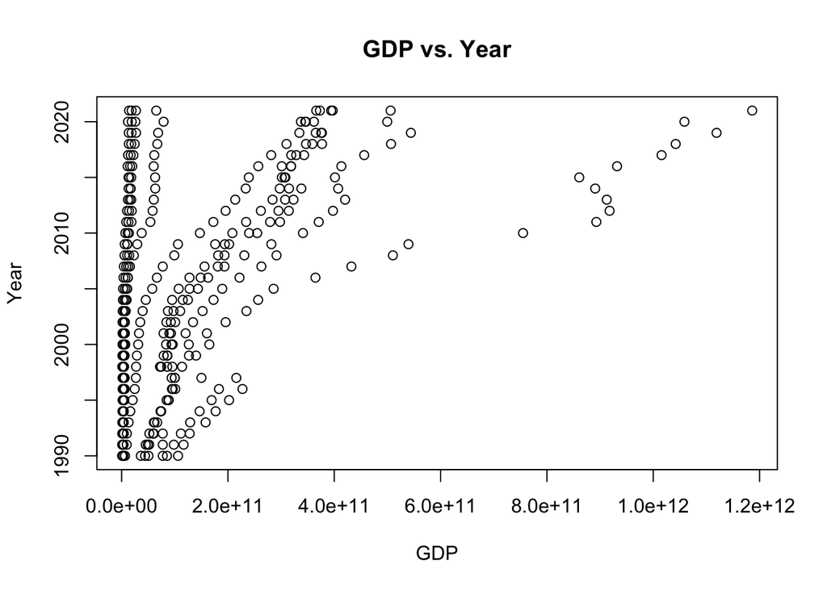

```r
plot(df$GDP, df$Year, main = "GDP vs. Year", xlab = "GDP", ylab = "Year")
```

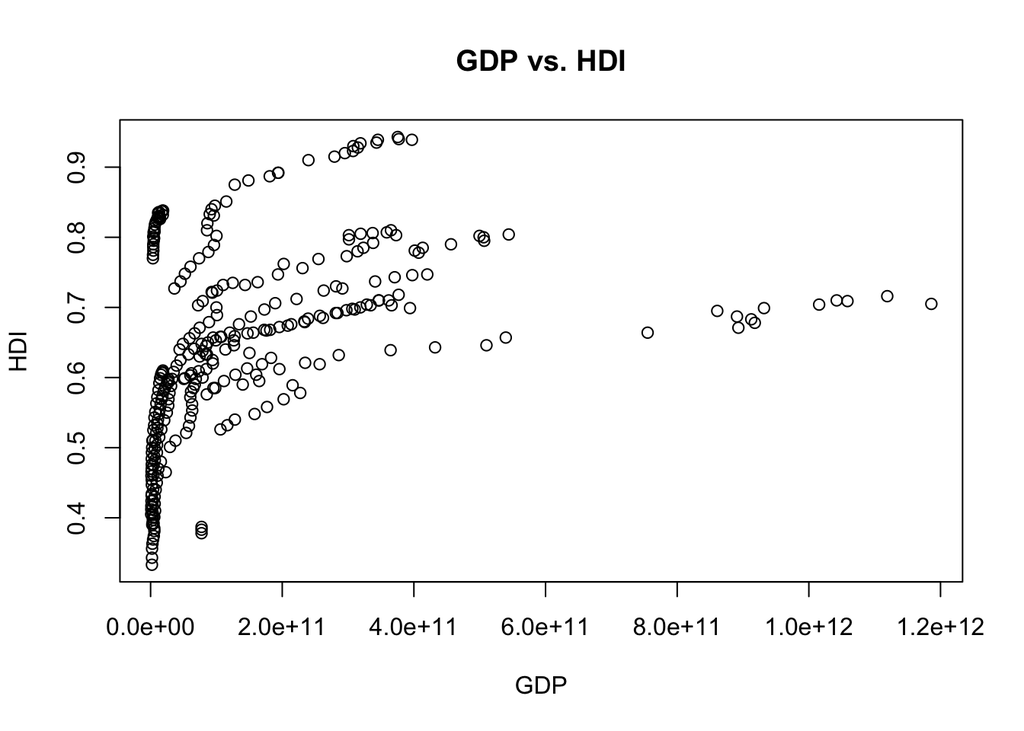

```r
plot(df$GDP, df$HDI, main = "GDP vs. HDI", xlab = "GDP", ylab = "HDI")
```

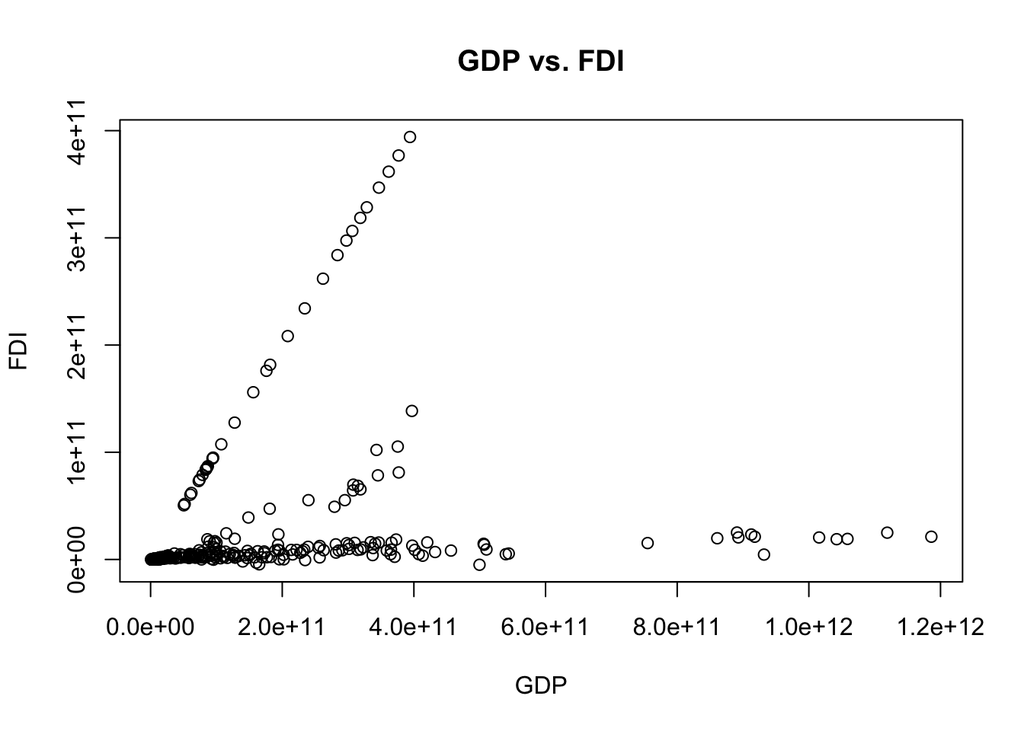

```r
plot(df$GDP, df$FDI, main = "GDP vs. FDI", xlab = "GDP", ylab = "FDI")
```

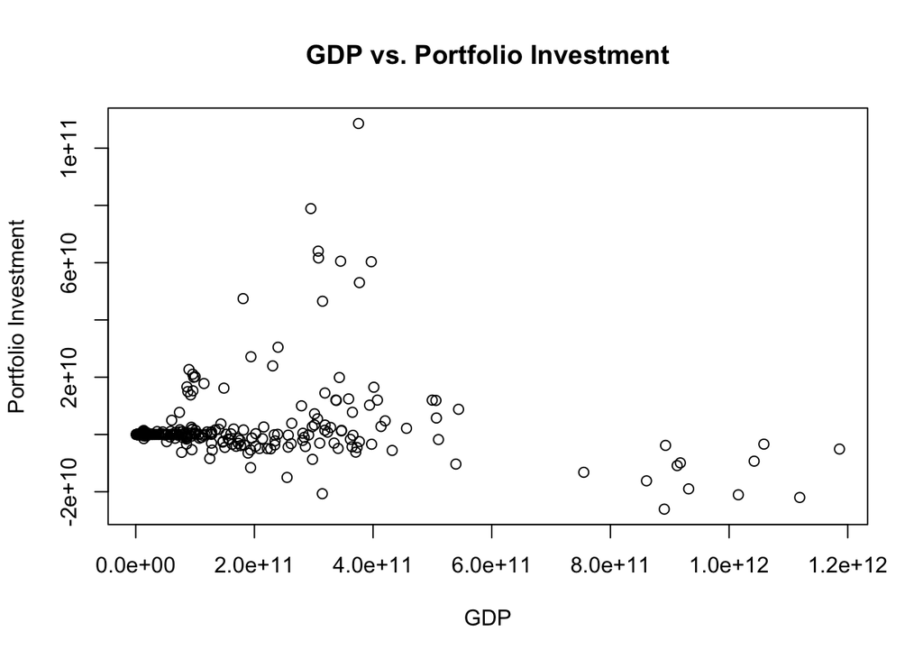

```r
plot(df$GDP, df$Portofolio_Investment, main = "GDP vs. Portfolio Investment", xlab = "GDP", ylab = "Portfolio Investment")
```

## Check GDP Normality

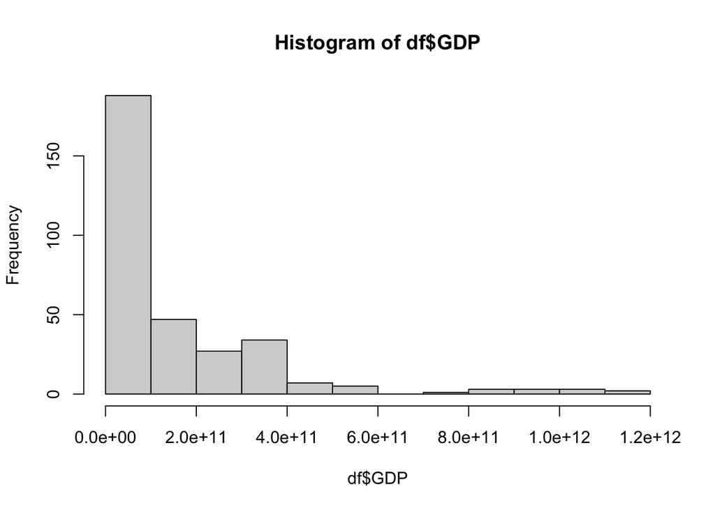

```r
hist(df$GDP)
```

Form the data above we can see that GDP is right skewed so we would do log transformation to the data

## Log Transformation

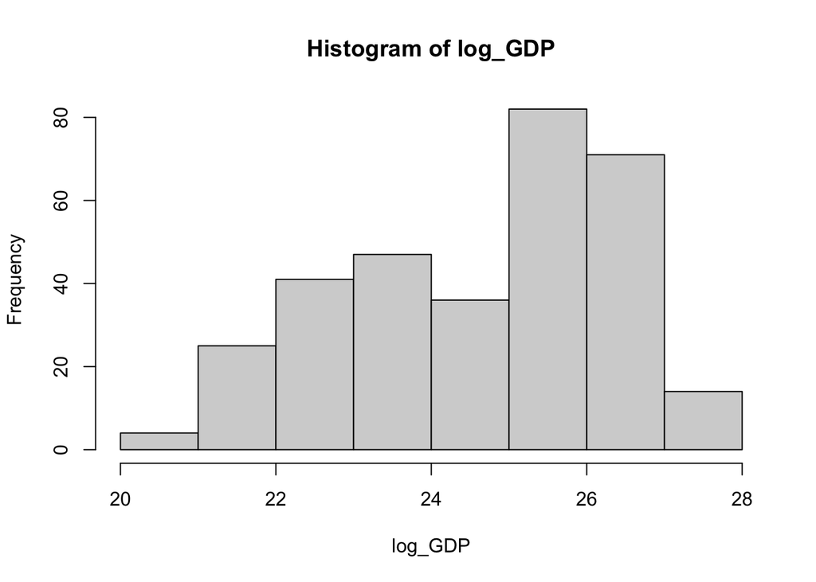

```r
log_GDP <- log(df$GDP)
hist(log_GDP)
```

```r
df$GDP <- log_GDP
```

The Logged Distribution is not right skewed anymore and can be assumed to me a normal even if it’s slightly skewed left

#### B. No multicollinearity

```r
reduced_data <- subset(df, select = -c(GDP, Countries))
cor(reduced_data)
```

```
##                            Year       HDI       FDI Portofolio_Investment
## Year                  1.0000000 0.4214126 0.2471400             0.1492177
## HDI                   0.4214126 1.0000000 0.1852592             0.3990422
## FDI                   0.2471400 0.1852592 1.0000000             0.1458384
## Portofolio_Investment 0.1492177 0.3990422 0.1458384             1.0000000
```

There us no strong correlation between each variables.

# Model 1 Fitting

```r
# Fit the multiple linear regression model
model1 = lm(GDP ~ Year + HDI + FDI + Portofolio_Investment, data = df)
```

## C. Multivariate Normality

let’s look at the residuals along the normal Q-Q plot. If there is normality, then the values should follow a straight line.

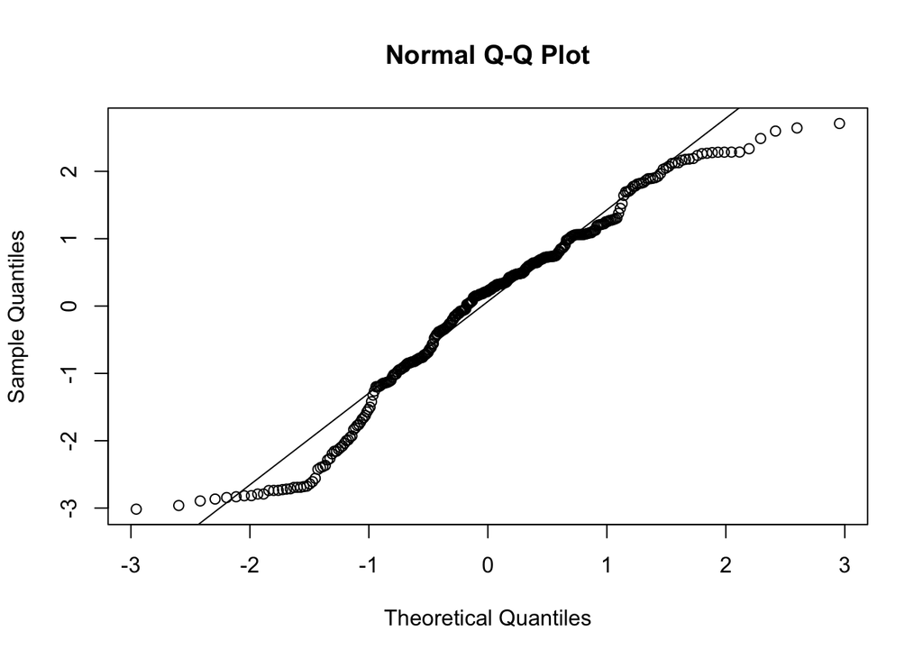

```r
# Get the model residuals
model_residuals = model1$residuals
qqnorm(model_residuals)
qqline(model_residuals)
```

Based on the QQ Plot Observation with the location of the point with the line, we can conclude that the data is slightly skewed but is still normal enough for our assumption.

## D. homoscedasticity

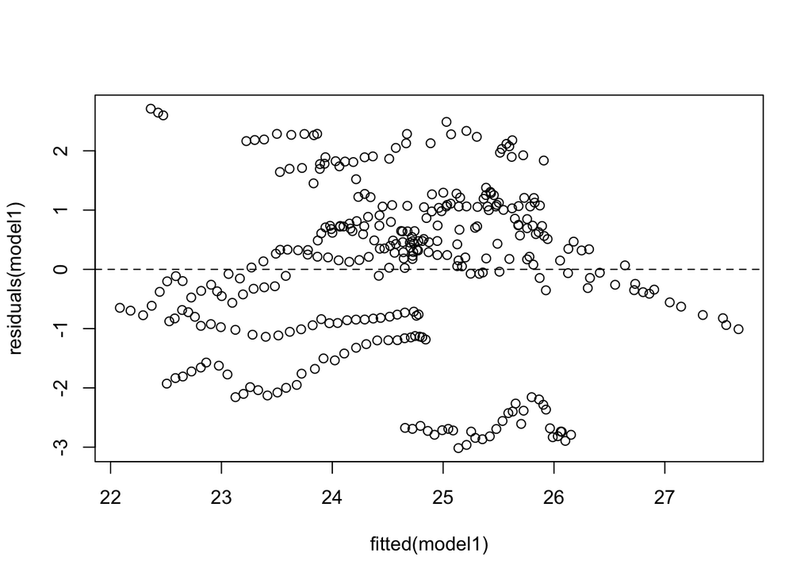

```r
#create fitted value vs residual plot
plot(fitted(model1), residuals(model1))

#add horizontal line at 0
abline(h = 0, lty = 2)
```

```r
summary(model1)
```

```
##
## Call:
## lm(formula = GDP ~ Year + HDI + FDI + Portofolio_Investment,
##     data = df)
##
## Residuals:
##     Min      1Q  Median      3Q     Max
## -3.0156 -0.8503  0.2205  0.9854  2.7102
##
## Coefficients:
##                         Estimate Std. Error t value Pr(>|t|)
## (Intercept)           -5.336e+01  1.873e+01  -2.849 0.004670 **
## Year                   3.692e-02  9.418e-03   3.920 0.000109 ***
## HDI                    5.890e+00  6.521e-01   9.032  < 2e-16 ***
## FDI                    5.849e-12  1.262e-12   4.636 5.21e-06 ***
## Portofolio_Investment -1.602e-11  6.687e-12  -2.396 0.017170 *
## ---
## Signif. codes:  0 '***' 0.001 '**' 0.01 '*' 0.05 '.' 0.1 ' ' 1
##
## Residual standard error: 1.384 on 315 degrees of freedom
## Multiple R-squared:  0.3946, Adjusted R-squared:  0.3869
## F-statistic: 51.33 on 4 and 315 DF,  p-value: < 2.2e-16
```

#8. Splitting data

```r
dfsub <- subset(df, select = -c(Countries))
set.seed(100)
n <- nrow(dfsub)
train <- sample(n, round(0.8 * n))
dfTrain <- dfsub[train, ]
dfVal <- dfsub[-train, ]
```

We split the data into validation and train sets.

#9. Fit the Linear/Logistic Regression Model

```r
LRmodel1 <- lm(GDP ~., dfTrain)
summary(LRmodel1)
```

```
##
## Call:
## lm(formula = GDP ~ ., data = dfTrain)
##
## Residuals:
##     Min      1Q  Median      3Q     Max
## -2.9132 -0.9096  0.2950  0.9082  2.6809
##
## Coefficients:
##                         Estimate Std. Error t value Pr(>|t|)
## (Intercept)           -5.969e+01  2.172e+01  -2.748 0.006422 **
## Year                   4.012e-02  1.092e-02   3.673 0.000293 ***
## HDI                    5.680e+00  7.498e-01   7.575 6.88e-13 ***
## FDI                    5.830e-12  1.426e-12   4.087 5.88e-05 ***
## Portofolio_Investment -1.790e-11  9.160e-12  -1.954 0.051802 .
## ---
## Signif. codes:  0 '***' 0.001 '**' 0.01 '*' 0.05 '.' 0.1 ' ' 1
##
## Residual standard error: 1.414 on 251 degrees of freedom
## Multiple R-squared:  0.3801, Adjusted R-squared:  0.3703
## F-statistic: 38.48 on 4 and 251 DF,  p-value: < 2.2e-16
```

From the Summary above we can see that Year, HDI, and FDI have a P-Value < 0.05 so we would use them for our next model.

# using variable which p-value < 0.05

```r
LRmodel2 <- lm(GDP ~ HDI + FDI + Year, dfTrain)
summary(LRmodel2)
```

```
##
## Call:
## lm(formula = GDP ~ HDI + FDI + Year, data = dfTrain)
##
## Residuals:
##     Min      1Q  Median      3Q     Max
## -2.7964 -0.9373  0.2535  0.9840  2.6138
##
## Coefficients:
##               Estimate Std. Error t value Pr(>|t|)
## (Intercept) -6.253e+01  2.179e+01  -2.870 0.004454 **
## HDI          5.152e+00  7.033e-01   7.325 3.22e-12 ***
## FDI          5.648e-12  1.431e-12   3.946 0.000103 ***
## Year         4.170e-02  1.095e-02   3.807 0.000177 ***
## ---
## Signif. codes:  0 '***' 0.001 '**' 0.01 '*' 0.05 '.' 0.1 ' ' 1
##
## Residual standard error: 1.421 on 252 degrees of freedom
## Multiple R-squared:  0.3707, Adjusted R-squared:  0.3632
## F-statistic: 49.48 on 3 and 252 DF,  p-value: < 2.2e-16
```

#10. Fit the Decision Tree Models

```r
DTmodel1 <- rpart(GDP ~., dfTrain) # with all variables
DTmodel1$variable.importance
```

```
##                   FDI                   HDI                  Year
##             582.66538             349.30599              88.93068
## Portofolio_Investment
##              75.90896
```

From the Importance level we would use the Top 2 variable with the highest importance level for our next model.

```r
DTmodel2 <- rpart(GDP ~ FDI + HDI, dfTrain)
DTmodel2$variable.importance
```

```
##      FDI      HDI
## 576.8976 394.7524
```

# generate plot

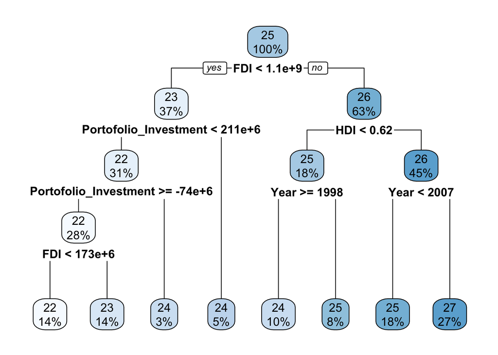

```r
rpart.plot(DTmodel1)
```

All result from this decision gives us GDP result in log(GDP). So to get the real GDP value in USD, we should do the log inverse.

In R we can use exp() function to find the log inverse value.

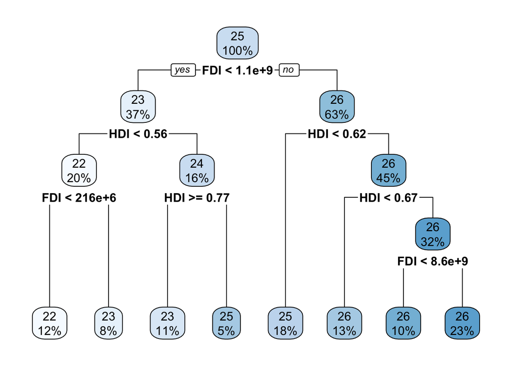

```r
rpart.plot(DTmodel2)
```

#11. Prediction

```r
PredLR1 <- predict(LRmodel1,dfVal)
PredLR2 <- predict(LRmodel2,dfVal)
PredDT1 <- predict(DTmodel1,dfVal)
PredDT2 <- predict(DTmodel2,dfVal)
```

#12. Performance (RMSE & r2Score) # Linear regression 1&2

```r
valLR1 <- RMSE(PredLR1, dfVal$GDP)
sprintf("RSME of Linear Regression 1 is %s",valLR1)
```

```
## [1] "RSME of Linear Regression 1 is 1.27061593577213"
```

```r
R2LR1 <- R2_Score(PredLR1, dfVal$GDP)
sprintf("R2 Score of Linear Regression 1 is %s",R2LR1)
```

```
## [1] "R2 Score of Linear Regression 1 is 0.439523426987875"
```

```r
valLR2 <- RMSE(PredLR2, dfVal$GDP)
sprintf("RSME of Linear Regression 2 is %s",valLR2)
```

```
## [1] "RSME of Linear Regression 2 is 1.28798680409515"
```

```r
R2LR2 <- R2_Score(PredLR2, dfVal$GDP)
sprintf("R2 Score of Linear Regression 2 is %s",R2LR2)
```

```
## [1] "R2 Score of Linear Regression 2 is 0.424093877076615"
```

# Decision Tree 1&2

```r
valDT1 <- RMSE(PredDT1, dfVal$GDP)
sprintf("RSME of Decision Tree 1 is %s",valDT1)
```

```
## [1] "RSME of Decision Tree 1 is 0.607403936708396"
```

```r
R2DT1 <- R2_Score(PredDT1, dfVal$GDP)
sprintf("R2 Score of Decision Tree 1 is %s",R2DT1)
```

```
## [1] "R2 Score of Decision Tree 1 is 0.871919187627926"
```

```r
valDT2 <- RMSE(PredDT2, dfVal$GDP)
sprintf("RSME of Decision Tree 2 is %s",valDT2)
```

```
## [1] "RSME of Decision Tree 2 is 0.830273406129333"
```

```r
R2DT2 <- R2_Score(PredDT2, dfVal$GDP)
sprintf("R2 Score of Decision Tree 2 is %s",R2DT2)
```

```
## [1] "R2 Score of Decision Tree 2 is 0.760684336866305"
```

#11. Conclusion Models with the highest R2 Score and Lowest RMSE is Decision Tree Model 1, therefore we will choose Decision Tree 1 for our prediction model for the GDP in ASEAN.

```r
accuracy <- 1 - mean((PredDT1 - dfVal$GDP)^2)/var(dfVal$GDP)
print(accuracy)
```

```
## [1] 0.8739205
```

The accuracy of Decision Tree Model 1 is 87%.